# Activity - human steps

Igaal Perez

22 juillet 2016

# Reproducible Research: Peer Assessment 1

For this project, we will process human activity data recorded on a cellular phone.

## 1. Loading and preprocessing the data

First we will load all the required libraries. We will read the file activity.csv Ensure you modify your working directory.

```r
library(dplyr)
```

```r
library(ggplot2)
library(stringr)
library(lattice)

setwd("C:/Users/IP/Documents")
activity<-read.table("activity.csv", sep=",",header=TRUE,  na.strings = "NA",
quote="'", stringsAsFactors = FALSE)
```

Let us have a look at the dataset “activity”. Column names and values are displayed with extra double quotes.

```r
head(activity)
```

```
##   X.steps      X..date.. X..interval...
## 1     "NA ""2012-10-01""             0"
## 2     "NA ""2012-10-01""             5"
## 3     "NA ""2012-10-01""            10"
## 4     "NA ""2012-10-01""            15"
## 5     "NA ""2012-10-01""            20"
## 6     "NA ""2012-10-01""            25"
```

Let us rename the column names and arrange the values by removing double quotes and setting the right formats.

```r
names(activity)<-c("steps", "date", "interval")

#removing quotes from values
activity$steps<-gsub('"', "",activity$steps)
activity$date<-gsub('"',"", activity$date)
activity$interval<-gsub('"', "",activity$interval)

#converting the dates to Date class
activity$date<-as.Date(activity$date, "%Y-%m-%d")

#converting the steps and  intyerval into numeric
activity$steps<-as.numeric(activity$steps)
activity$interval<-as.numeric(activity$interval)
```

Now the dataset look tidy.

```r
head(activity)
```

```
##   steps       date interval
## 1    NA 2012-10-01        0
## 2    NA 2012-10-01        5
## 3    NA 2012-10-01       10
## 4    NA 2012-10-01       15
## 5    NA 2012-10-01       20
## 6    NA 2012-10-01       25
```

Let us have a look on the histogram of total daily steps.

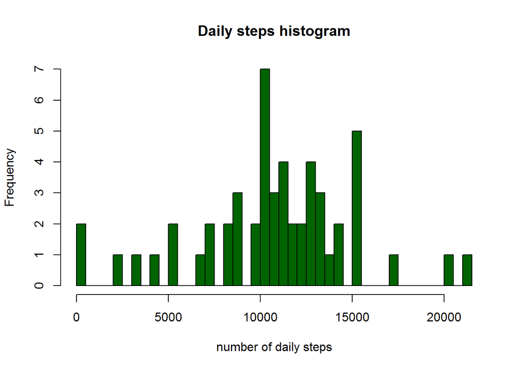

```r
# Plotting histogram of total daily steps
byday<-group_by(activity, date)
activitybyday<-summarise(byday, dailysteps=sum(steps))
hist(activitybyday$dailysteps, breaks=40, main="Daily steps histogram",
     xlab="number of daily steps", col="dark green")
```

## 3. What is the average daily activity pattern?

```r
activitymeanmedian<-summarise(byday,meansteps=mean(steps, na.rm=TRUE),
                              mediansteps=median(steps, na.rm=TRUE))
print(activitymeanmedian)
```

```
## Source: local data frame [61 x 3]
##
##          date meansteps mediansteps
##        (date)     (dbl)       (dbl)
## 1  2012-10-01       NaN          NA
## 2  2012-10-02   0.43750           0
## 3  2012-10-03  39.41667           0
## 4  2012-10-04  42.06944           0
## 5  2012-10-05  46.15972           0
## 6  2012-10-06  53.54167           0
## 7  2012-10-07  38.24653           0
## 8  2012-10-08       NaN          NA
## 9  2012-10-09  44.48264           0
## 10 2012-10-10  34.37500           0
## ..        ...       ...         ...
```

Let us now plot the average number of steps by interval:

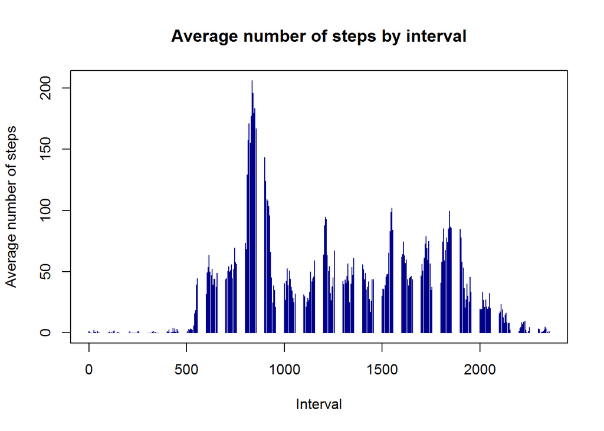

```r
byinterval<-group_by(activity, interval)
activitybyinterval<-summarise(byinterval, averagesteps=mean(steps, na.rm=TRUE))
plot(activitybyinterval$interval, activitybyinterval$averagesteps, type="h", main="Average number of steps by interval"
     , xlab="Interval", ylab="Average number of steps", col="dark blue")
```

We will also find the interval on which the maximum number of steps in average occurs.

```r
print(paste("The maximum number of steps occurs at interval",
      activitybyinterval$interval[which.max(activitybyinterval$averagesteps)],
      "on average across all days."))
```

```
## [1] "The maximum number of steps occurs at interval 835 on average across all days."
```

## 4. Imputing missing values

First let us check how many values are missing:

```r
missing<-is.na(activity$steps)
table(missing)
```

```
## missing
## FALSE  TRUE
## 15264  2304
```

```r
print("There are 2304 missing values in the activity dataset.")
```

```
## [1] "There are 2304 missing values in the activity dataset."
```

Then, let us create a new dataset whith imputed missing values: NAs are replaced by the mean valuee for the same interval. We will create and use the dataset “activityfilled”.

```r
activityfilled<-activity
fillingbyinterval<-function(x, intervalofx){
    if (is.na(x) | is.nan(x))   {
     x<-activitybyinterval$averagesteps[activitybyinterval$interval==intervalofx]
    } else {
        x=x
    }
}

for(i in 1:17568) {activityfilled$steps[i]<-fillingbyinterval(activityfilled$steps[i], activityfilled$interval[i])}

head(activityfilled)
```

```
##       steps       date interval
## 1 1.7169811 2012-10-01        0
## 2 0.3396226 2012-10-01        5
## 3 0.1320755 2012-10-01       10
## 4 0.1509434 2012-10-01       15
## 5 0.0754717 2012-10-01       20
## 6 2.0943396 2012-10-01       25
```

We can compare the “activityfilled” dataset to the “activity”" dataset and check there are no more missing values:

```r
missingfilled<-is.na(activityfilled$steps)
table(missingfilled)
```

```
## missingfilled
## FALSE
## 17568
```

Now we can plot the histogram of daily total steps when all missing values are replaced.

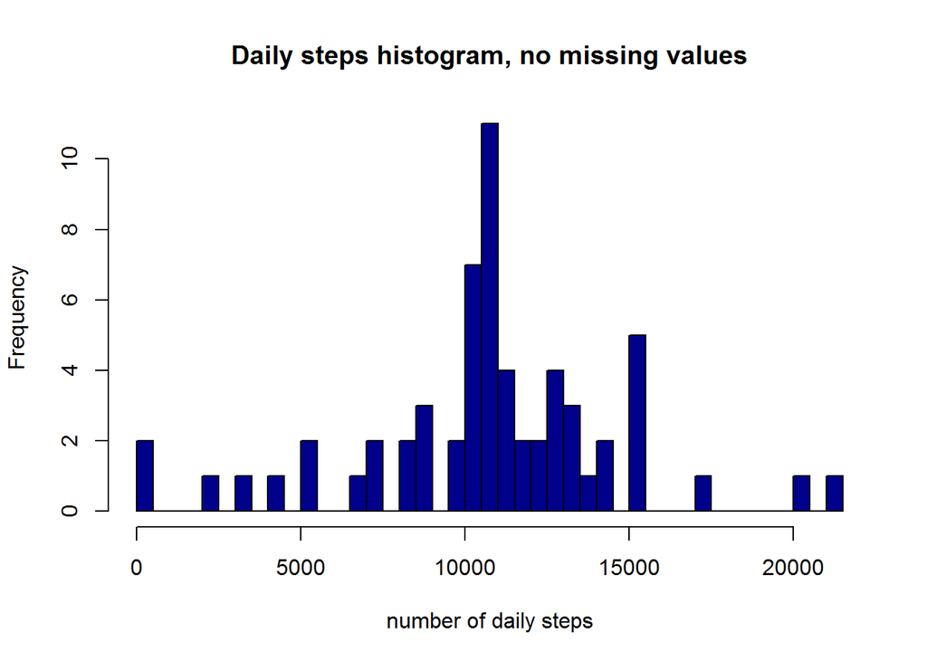

```r
bydayfilled<-group_by(activityfilled, date)
activityfilledbyday<-summarise(bydayfilled, dailysteps=sum(steps))
hist(activityfilledbyday$dailysteps, breaks=40, main="Daily steps histogram, no missing values",
     xlab="number of daily steps", col="dark blue")
```

```r
activityfilledmeanmedian<-summarise(bydayfilled,meansteps=mean(steps, na.rm=TRUE),
                              mediansteps=median(steps, na.rm=TRUE))
print(activityfilledmeanmedian)
```

```
## Source: local data frame [61 x 3]
##
##          date meansteps mediansteps
##        (date)     (dbl)       (dbl)
## 1  2012-10-01  37.38260    34.11321
## 2  2012-10-02   0.43750     0.00000
## 3  2012-10-03  39.41667     0.00000
## 4  2012-10-04  42.06944     0.00000
## 5  2012-10-05  46.15972     0.00000
## 6  2012-10-06  53.54167     0.00000
## 7  2012-10-07  38.24653     0.00000
## 8  2012-10-08  37.38260    34.11321
## 9  2012-10-09  44.48264     0.00000
## 10 2012-10-10  34.37500     0.00000
## ..        ...       ...         ...
```

## 5. Are there differences in activity patterns between weekdays and weekends?

To answer this question, we will create a factor variable to check which day is a weekday or a weekend.

```r
typeofday<-function(jour){
    if(tolower(weekdays(jour)) %in% c("samedi", "dimanche")) {
        "weekend"
    } else {
        "weekday"
    }
}
```

We will add a new column “type” in which will be stored the type of weekday according to its date:

```r
activityfilled<-mutate(activityfilled, type=NULL)
for (j in 1:17568){
    activityfilled$type[j]<-typeofday(activityfilled$date[j])
}
head(activityfilled)
```

```
##       steps       date interval    type
## 1 1.7169811 2012-10-01        0 weekday
## 2 0.3396226 2012-10-01        5 weekday
## 3 0.1320755 2012-10-01       10 weekday
## 4 0.1509434 2012-10-01       15 weekday
## 5 0.0754717 2012-10-01       20 weekday
## 6 2.0943396 2012-10-01       25 weekday
```

Let us group by interval and type. Then we plot using lattice system.

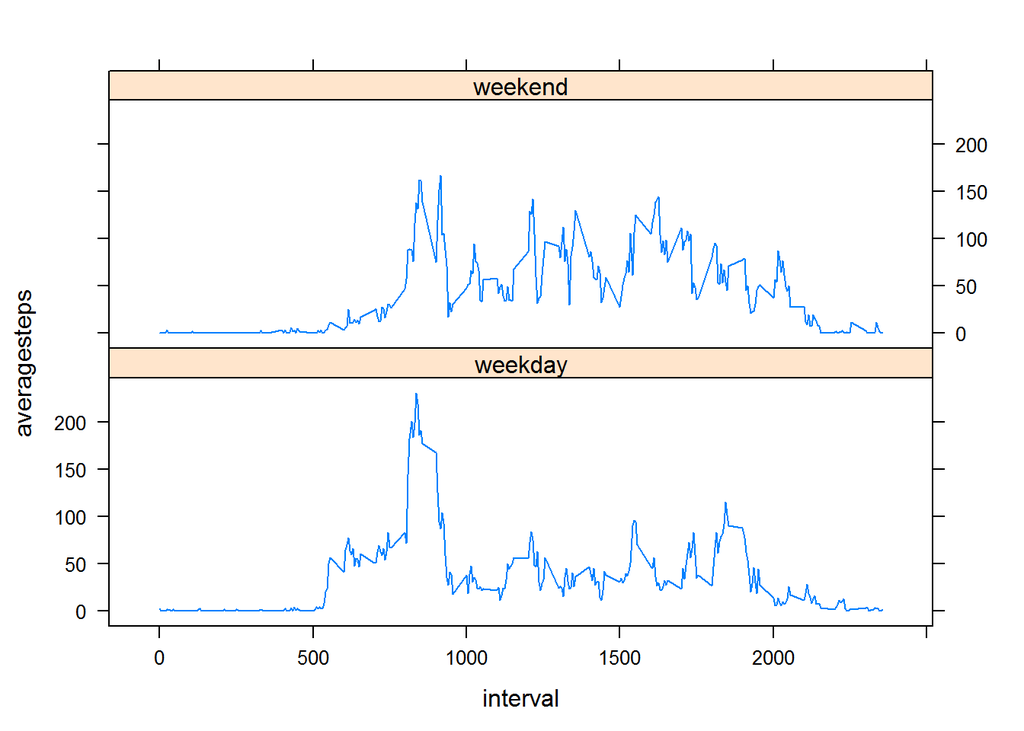

```r
filledbyinterval<-group_by(activityfilled, interval, type)
activityfilledbyinterval<-summarise(filledbyinterval, averagesteps=mean(steps, na.rm=TRUE))

xyplot(averagesteps ~ interval | type, data= activityfilledbyinterval, layout=c(1, 2), type="l")
```

```r
#releasing the graphical device
dev.off()
```

```r
dev.set(which = 2)
```